# task 1.2.2

# Permutation test

The goal of this analysis is to investigate correlation between the variables Bill and Tip expressed as a percentage on the bill.

We are going to perform the permutation test on the hypothesis `H0: cov(Bill,PctTip)==0` vs. `H1: cov(Bill,PctTip)!=0`

```r
 knitr::opts_chunk$set(echo = TRUE)
```

```r
library(ggplot2)
library(gtools)
library(combinat)
library(Rfast)
```

```r
load("RestaurantTips.rda")
```

#### Exploring the data’s distribution

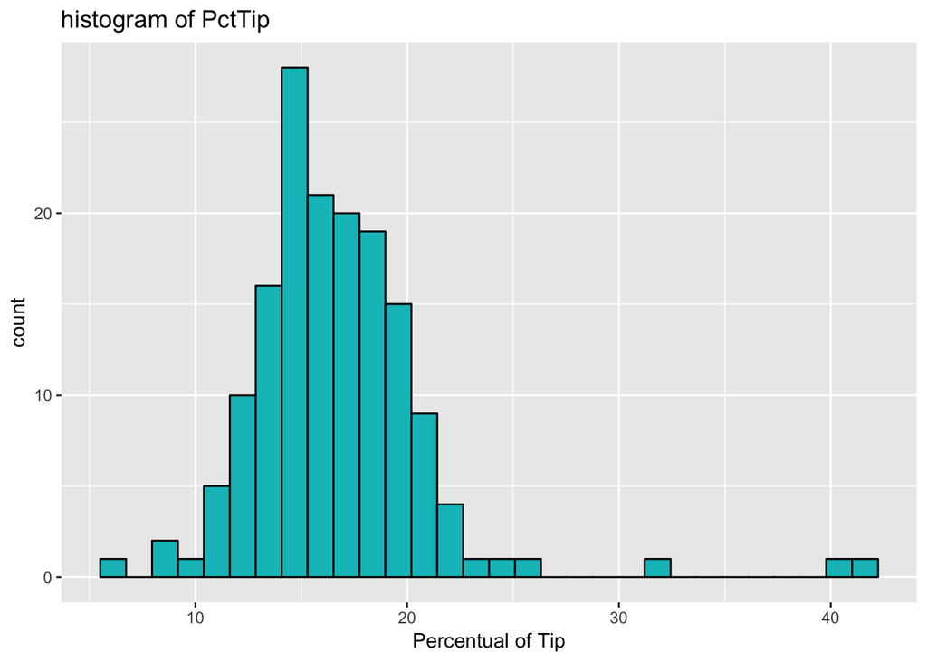

```r
Rest<-RestaurantTips

ggplot(RestaurantTips, aes(x=Rest$PctTip)) +
  geom_histogram(fill='#00BFC4', color="black", bins = 30) +
  xlab("Percentual of Tip") +
  ggtitle("histogram of PctTip", subtitle = NULL)
```

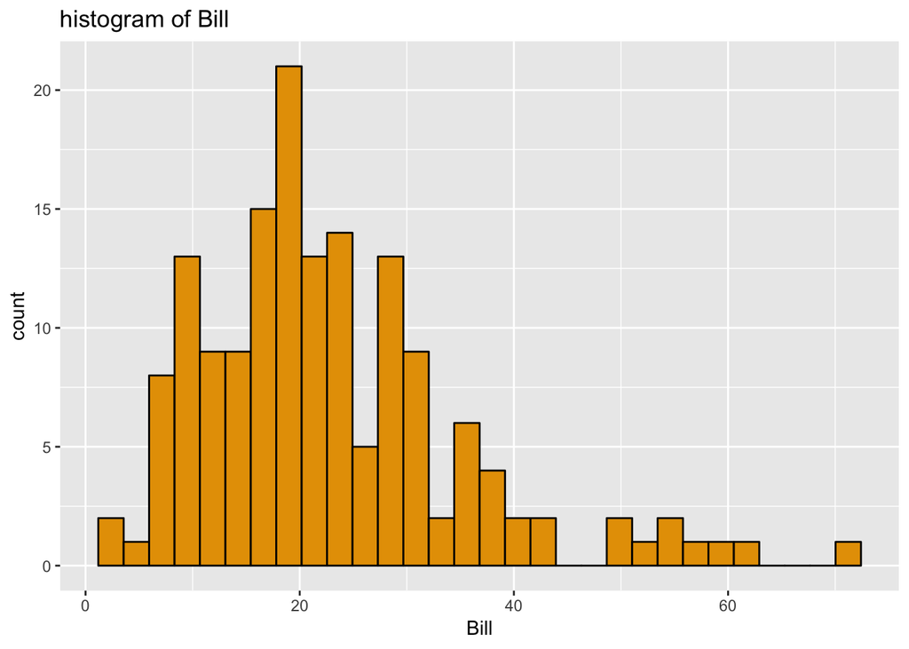

```r
ggplot(RestaurantTips, aes(x=Rest$Bill)) +
  geom_histogram(fill='#E69F00', color="black", bins = 30) +
  xlab("Bill") +
  ggtitle("histogram of Bill", subtitle = NULL)
```

Compute the Pearson correlation coefficient

```r
co=cor(Rest$Bill,Rest$PctTip,method='pearson')
co
```

```
## [1] 0.1352976
```

Look at the scatterplot Bill vs. PctTip

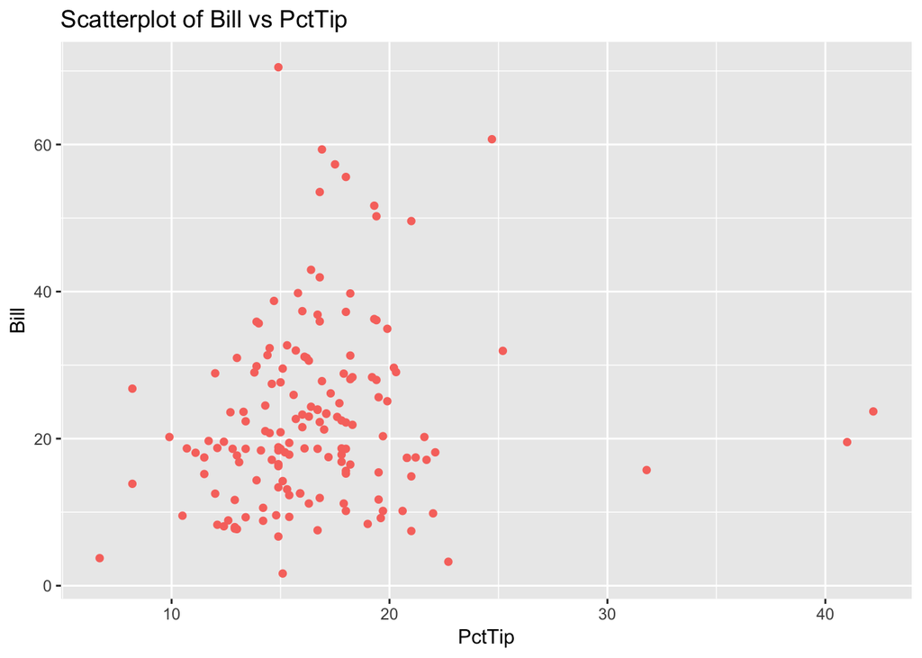

```r
ggplot(data=Rest,aes(x=Rest$PctTip,y=Rest$Bill)) +
  geom_point(color = "#F8766D")+
  xlab('PctTip')+
  ylab('Bill') +
  ggtitle("Scatterplot of Bill vs PctTip", subtitle = NULL)
```

From here, there’s no evidence for confirming or rejecting one of the two hypotesis.

### R Pre-implemented permutation test

```r
#I set a seed because of randomness of the test
set.seed(7)
nreps=10000
permcor(Rest$Bill,Rest$PctTip,R=nreps)
```

```
##        cor    p-value
## 0.13529758 0.09019098
```

### Permutation test

```r
r.obt=co

# in order to avoid the for loop we instantiate a matrix of 10000 x 157,
y_matrix <- matrix(Rest$PctTip, nrow=nreps, ncol=length(Rest$PctTip),byrow=TRUE)

# in each row there is a permutation of the variable PctTip.
y_matrix_shuffled <- t(apply(y_matrix, MARGIN=1, FUN=function(x) permute(x)))

# then, we compute the array of the 157 correlatioin coefficent, comparing the non-shuffled variable Bill,
# with each row of the matrix.
corr_vector <- apply(y_matrix_shuffled, MARGIN=1, FUN = function(x) cor(x, Rest$Bill))

prob <- length(corr_vector[abs(corr_vector) >= abs(r.obt)])/nreps

cat("P-value of the permutation test ",prob)
```

```
## P-value of the permutation test  0.088
```

The p-value is quite high, so i will accept H0 as true, so the two variables ar uncorrelated.

Histogram of the distribution of r among the simulations, the red line stays for the Pearson correlation coefficient

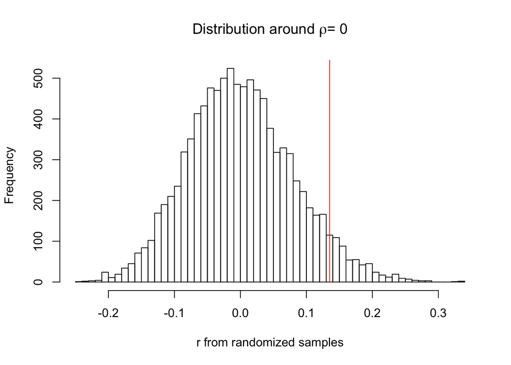

```r
hist(corr_vector, breaks = 50, main =  expression(paste("Distribution around ",rho, "= 0")), xlab = "r from randomized samples")
a=c(co,co)
b=c(co,1000)
lines(a,b,col='red')
```

## Without outilers

##### Now i repeat the analysis whitout the outliers (percentage tip>30%)

```r
Rest<-Rest[Rest$PctTip<30,]
```

#### Exploring the data’s distribution

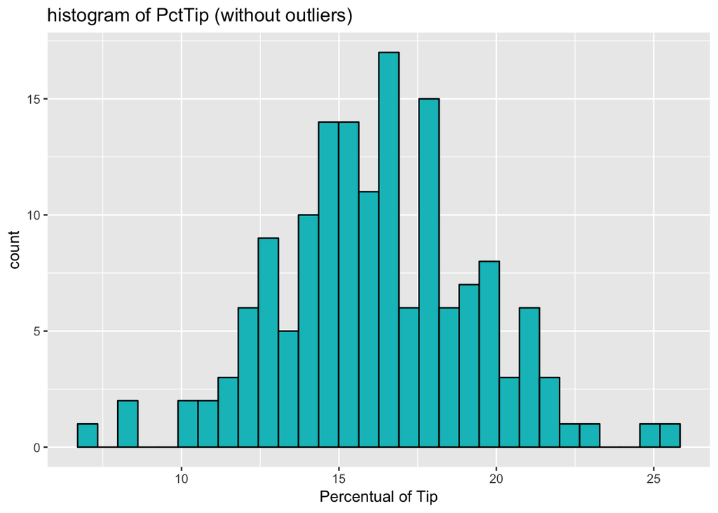

```r
ggplot(Rest, aes(x=Rest$PctTip)) +
  geom_histogram(fill='#00BFC4', color="black", bins = 30) +
  xlab("Percentual of Tip") +
  ggtitle("histogram of PctTip (without outliers) ", subtitle = NULL)
```

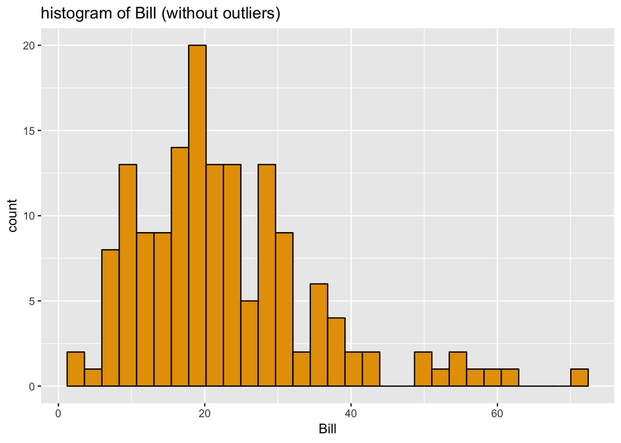

```r
ggplot(Rest, aes(x=Rest$Bill)) +
  geom_histogram(fill='#E69F00', color="black", bins = 30) +
  xlab("Bill") +
  ggtitle("histogram of Bill (without outliers) ", subtitle = NULL)
```

Compute the Pearson correlation coefficient

```r
co=cor(Rest$Bill,Rest$PctTip,method='pearson')
co
```

```
## [1] 0.2198554
```

Look at the scatterplot Bill vs. PctTip

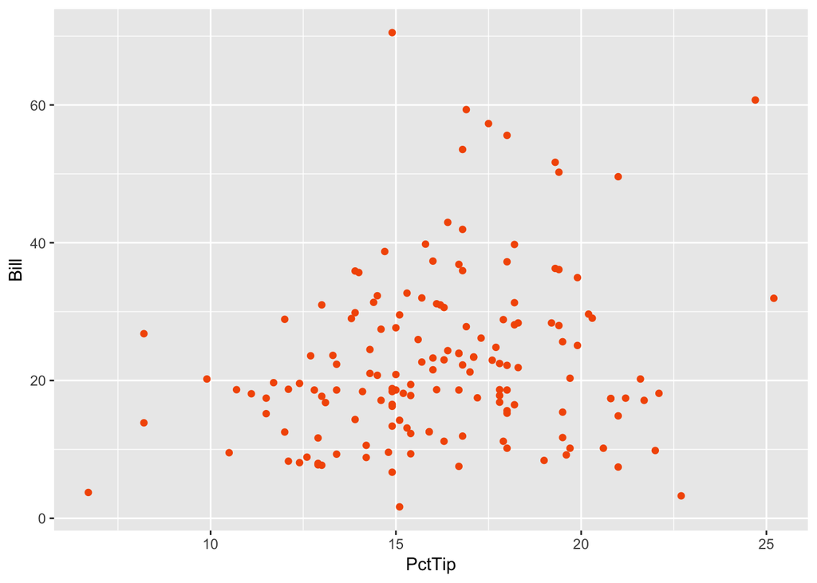

```r
ggplot(data=Rest,aes(x=Rest$PctTip,y=Rest$Bill)) +
  geom_point(color = "#F45903")+
  xlab('PctTip')+
  ylab('Bill')
```

Can see a weak correlation.

### R Pre-implemented permutation test

```r
#I set a seed because of randomness of the test
#set.seed(7)
nreps=10000
permcor(Rest$Bill,Rest$PctTip,R=nreps)
```

```
##        cor    p-value
## 0.21985542 0.00729927
```

### Permutation test

```r
r.obt=co
y_matrix <- matrix(Rest$PctTip, nrow=nreps, ncol=length(Rest$PctTip),byrow=TRUE)
y_matrix_shuffled <- t(apply(y_matrix, MARGIN=1, FUN=function(x) permute(x)))
corr_vector <- apply(y_matrix_shuffled, MARGIN=1, FUN = function(x) cor(x, Rest$Bill))

prob <- length(corr_vector[abs(corr_vector) >= abs(r.obt)])/nreps

cat("P-value of the permutation test ",prob)
```

```
## P-value of the permutation test  0.0061
```

Since the p-value is very low, we have statistical evidence that the two variables ar correlated.

Histogram of the distribution of r among the simulations, the red line stays for the Pearson correlation coefficient

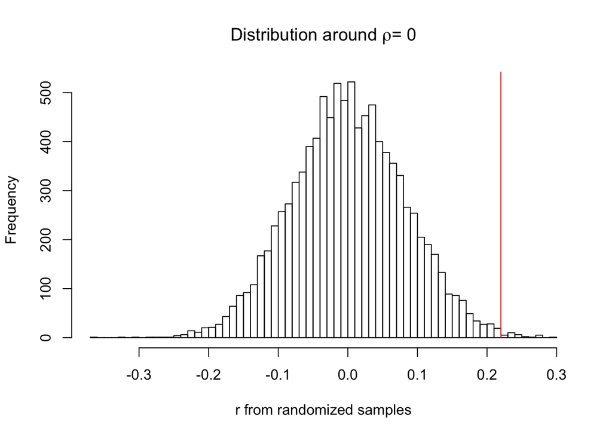

```r
hist(corr_vector, breaks = 50, main =  expression(paste("Distribution around ",rho, "= 0")), xlab = "r from randomized samples")
a=c(co,co)
b=c(co,1000)
lines(a,b,col='red')
```